# Problem Set 2

Author

Noel Hernandez

Published

**GitHub repo:** https://github.com/noelhernandez217/ec422_ps2_noelh

### 1. Data

```r
library(tidyquant)
library(tidyverse)
# unemp_raw <- tq_get(
#   c("UNRATE", "ORUR", "CAUR", "TXUR", "NYUR"),
#   get  = "economic.data",
#   from = "1976-01-01"
# )
#
# head(unemp_raw)
#
# dir.create("data", showWarnings = FALSE)
#
# write_rds(unemp_raw, "data/unemp_raw.rds")

unemp_raw = read_rds("data/unemp_raw.rds")

unemp <- unemp_raw |>
  rename(unemployment_rate = price) |>
  mutate(
    region = case_when(
      symbol == "UNRATE" ~ "United States",
      # I set the matching symbols here
      symbol == "ORUR" ~ "Oregon",
      symbol == "CAUR" ~ "California",
      symbol == "TXUR" ~ "Texas",
      symbol == "NYUR" ~ "New York"
          )
  )

head(unemp)
```

```
# A tibble: 6 × 4
  symbol date       unemployment_rate region
  <chr>  <date>                 <dbl> <chr>
1 UNRATE 1976-01-01               7.9 United States
2 UNRATE 1976-02-01               7.7 United States
3 UNRATE 1976-03-01               7.6 United States
4 UNRATE 1976-04-01               7.7 United States
5 UNRATE 1976-05-01               7.4 United States
6 UNRATE 1976-06-01               7.6 United States
```

### 2. Wrangling

Setting up the main dataframe we will be working from.

```r
unemp <- unemp |>
  arrange(region, date) |>
  group_by(region) |>
  mutate(
    unemployment_rate = replace(
      unemployment_rate,
      date == as.Date("2025-10-01"),
      unemployment_rate[date == as.Date("2025-09-01")]
    )
  ) |>
  ungroup()

unemp <- unemp |>
  arrange(region, date) |>
  group_by(region) |>
  mutate(unemployment_rate_change = unemployment_rate - lag(unemployment_rate)) |>
  ungroup()

head(unemp)
```

```
# A tibble: 6 × 5
  symbol date       unemployment_rate region     unemployment_rate_change
  <chr>  <date>                 <dbl> <chr>                         <dbl>
1 CAUR   1976-01-01               9.2 California                  NA
2 CAUR   1976-02-01               9.2 California                   0
3 CAUR   1976-03-01               9.1 California                  -0.1000
4 CAUR   1976-04-01               9   California                  -0.1000
5 CAUR   1976-05-01               8.9 California                  -0.1000
6 CAUR   1976-06-01               8.9 California                   0
```

Here is the table for recent unemployment.

```r
unemp_recent <- filter(unemp, date > as.Date("2015-01-01"))
head(unemp_recent)
```

```
# A tibble: 6 × 5
  symbol date       unemployment_rate region     unemployment_rate_change
  <chr>  <date>                 <dbl> <chr>                         <dbl>
1 CAUR   2015-02-01               6.7 California                  -0.1000
2 CAUR   2015-03-01               6.6 California                  -0.100
3 CAUR   2015-04-01               6.5 California                  -0.1000
4 CAUR   2015-05-01               6.4 California                  -0.1000
5 CAUR   2015-06-01               6.3 California                  -0.100
6 CAUR   2015-07-01               6.1 California                  -0.200
```

Here is the summary statistics table. What it does is group by the region. So the granularity of this data is by state, and for each state we have the mean, minimum and maximum rates of unemployment. We also have a base of comparison by including the countries rate as a whole.

```r
unemp_summary <- unemp |>
  group_by(region) |>
  summarize(
    mean_rate = mean(unemployment_rate, na.rm = TRUE),
    min_rate  = min(unemployment_rate,  na.rm = TRUE),
    max_rate  = max(unemployment_rate,  na.rm = TRUE)
  )

head(unemp_summary)
```

```
# A tibble: 5 × 4
  region        mean_rate min_rate max_rate
  <chr>             <dbl>    <dbl>    <dbl>
1 California         7.07      3.8     16.1
2 New York           6.35      3.8     16.7
3 Oregon             6.66      3.4     13.7
4 Texas              5.85      3.4     12.8
5 United States      6.05      3.4     14.8
```

This shows the top 5 month to month unemployment rate changes. That is captured by the unemployment_rate_change variable.

```r
unemp_top_increases_no_covid <- unemp |> filter(year(date) != 2020) |> slice_max(unemployment_rate_change, n = 5, with_ties = TRUE)

head(unemp_top_increases_no_covid)
```

```
# A tibble: 6 × 5
  symbol date       unemployment_rate region        unemployment_rate_change
  <chr>  <date>                 <dbl> <chr>                            <dbl>
1 TXUR   2009-05-01               7.6 Texas                            1.1
2 ORUR   2008-12-01               8.9 Oregon                           0.700
3 ORUR   2008-11-01               8.2 Oregon                           0.700
4 ORUR   2009-01-01               9.6 Oregon                           0.700
5 ORUR   1980-03-01               7.4 Oregon                           0.600
6 UNRATE 1980-04-01               6.9 United States                    0.600
```

This shows the top 5 lowest month to month unemployment rate changes. This uses the same variable as before.

```r
unemp_top_decreases_no_covid <- unemp |> filter(year(date) != 2020) |> slice_min(unemployment_rate_change, n = 5, with_ties = TRUE)

head(unemp_top_decreases_no_covid)
```

```
# A tibble: 6 × 5
  symbol date       unemployment_rate region        unemployment_rate_change
  <chr>  <date>                 <dbl> <chr>                            <dbl>
1 UNRATE 1983-07-01               9.4 United States                   -0.700
2 NYUR   2021-09-01               6.2 New York                        -0.600
3 ORUR   1977-05-01               7.8 Oregon                          -0.500
4 CAUR   2021-07-01               7.4 California                      -0.5
5 CAUR   2021-09-01               6.5 California                      -0.5
6 NYUR   2021-07-01               7   New York                        -0.5
```

### 3. Visualization

Here are the four 4 required plots. The last one is the one I created.

This first plot is a line plot of the changing unemployment rate for all four states, and then the country as a whole.

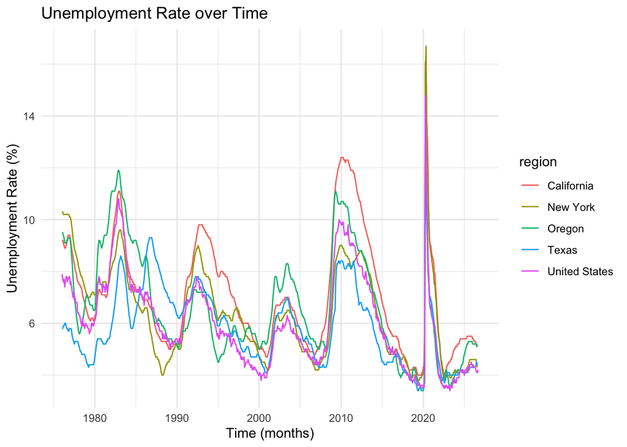

```r
ggplot(unemp, aes(x = date, y = unemployment_rate, color = region)) +
  geom_line() +        # or geom_col(), geom_point(), etc.
  labs(title = "Unemployment Rate over Time", x = "Time (months)", y = "Unemployment Rate (%)") +
  theme_minimal()
```

This one splits the previous line plot where we have everything all together into separate line plots where we focus on the states and the country individually. This is done with the facet_wrap(~ region).

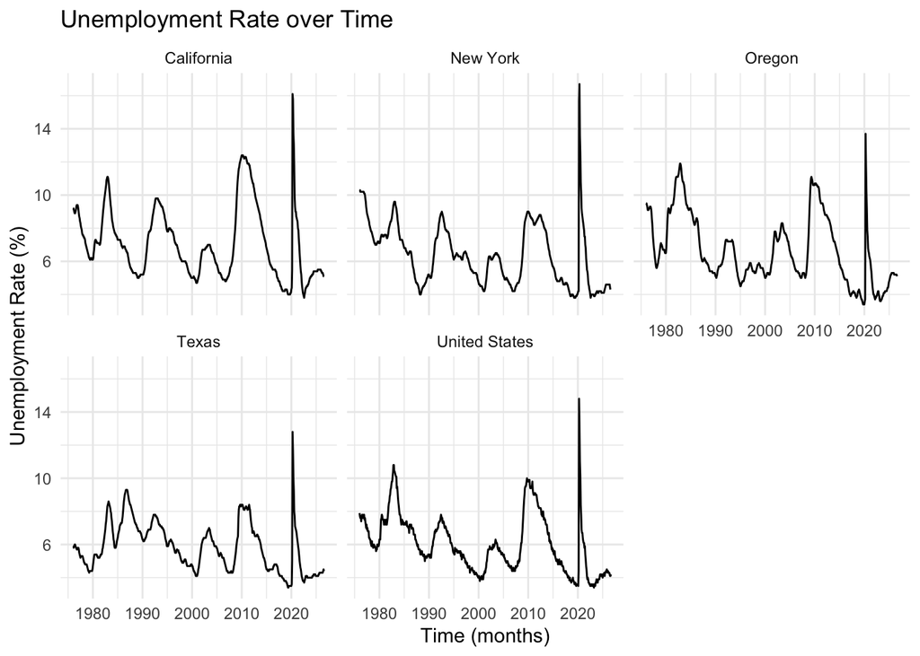

```r
ggplot(unemp, aes(x = date, y = unemployment_rate)) +
  geom_line() + facet_wrap(~ region) +    # or geom_col(), geom_point(), etc.
  labs(title = "Unemployment Rate over Time", x = "Time (months)", y = "Unemployment Rate (%)") +
  theme_minimal()
```

This bar plot uses the summary statistics table to compare the mean unemployment rates by region.

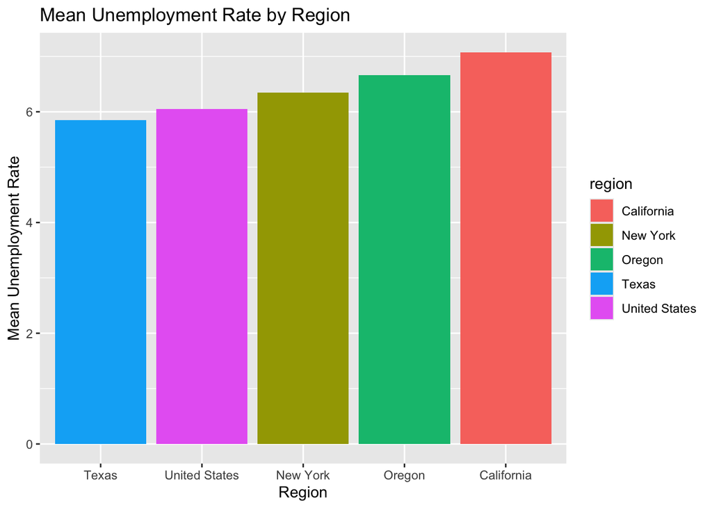

```r
ggplot(unemp_summary, aes(x = fct_reorder(region, mean_rate), y = mean_rate, fill = region)) +
  labs(
    title = "Mean Unemployment Rate by Region",
    x = "Region",
    y = "Mean Unemployment Rate"
  ) +
  geom_col()
```

This is the plot I created. I wanted to plot the month to month changes in unemployment and compare that to the actual unemployment rate by region. I used the same face_wrap(~ region) to do this for the four states and then the country.

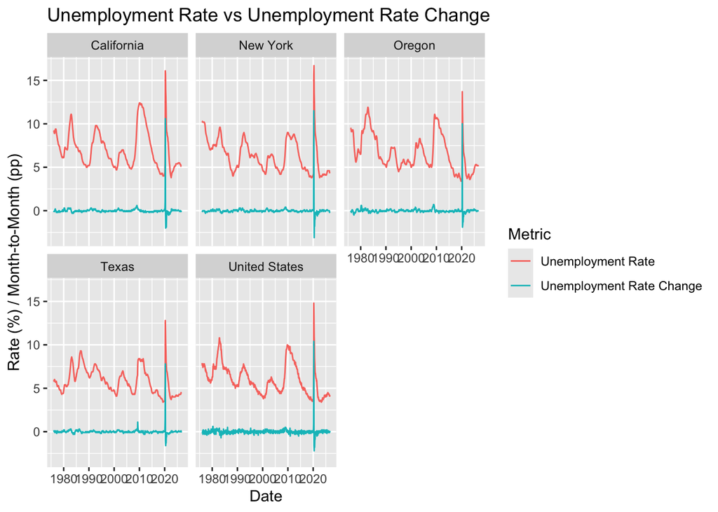

```r
rate_vs_change <- ggplot(unemp, aes(x = date)) +
  geom_line(aes(y = unemployment_rate, color = "Unemployment Rate")) +
  geom_line(aes(y = unemployment_rate_change, color = "Unemployment Rate Change")) +
  facet_wrap(~ region) +
  labs(
    title = "Unemployment Rate vs Unemployment Rate Change",
    x = "Date",
    y = "Rate (%) / Month-to-Month (pp)",
    color = "Metric"
  )

rate_vs_change
```

### 4. Reflection

I’ve used github before so the stage, commit, and push process isn’t new to me. I’ve done it through the terminal before. I think I just needed a refresher on R coding. I’ve used other similar things like pandas so that helps a lot. I was taught R in EC 320 which I took last year and I did a lot more R in EC 421. I don’t really like github copilot so I disabled it. I didn’t have any crazy errors, I would just look at documentation online for how to use specific functions (geeksforgeeks is really helpful). I also haven’t touched R studio since then and I didn’t know you could link R studio to github like this so that was cool.